# Data dimentionality and linear dimensional reduction

### Determining dataset dimentionality

To overcome the extensive technical noise in any single feature for scRNA-seq data, Seurat clusters cells based on their PCA scores, with each PC essentially representing a ‘metafeature’ that combines information across a correlated feature (gene) set. The top principal components therefore represent a robust compression of the dataset. However, how many componenets should we choose to include? 10? 20? 100?

In Macosko et al, the authors implemented a resampling test inspired by the JackStraw procedure. Here, we will randomly permute a subset of the data (1% = 100 replicates) and rerun PCA, constructing a ‘null distribution’ of feature scores, and repeat this procedure. We identify ‘significant’ PCs as those who have a strong enrichment of low p-value features.

Let’s run this and take a quick break:

```r
# NOTE: This process can take a long time for big datasets or older processors. More approximate techniques such as those implemented in ElbowPlot can be used to reduce computation time
pbmc <- JackStraw(pbmc, num.replicate = 100)
```

[output not shown]

[output cut: 68 more lines]

[output not shown]

```r
pbmc <- ScoreJackStraw(pbmc, dims = 1:20)
```

The `JackStrawPlot` function provides a visualization tool for comparing the distribution of p-values for each PC with a uniform distribution (dashed line). ‘Significant’ PCs will show a strong enrichment of features with low p-values (solid curve above the dashed line). In this case it appears that there is a sharp drop-off in significance after the first 10-12 PCs. This distinction will not be clear with only 10 replicates (0.1% subset of the data), showing the importance of replicate number. Compare the graphs in the `jackstraw_permutations` folder. Doing the full 100 gives us statistical power.

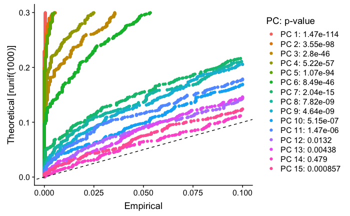

```r
JackStrawPlot(pbmc, dims = 1:15)
```

```r
#Examples showing how increasing replicates increased statistical power are on GitHub and CLE
```

Perhaps the most commonly used heuristic method generates an ‘Elbow plot’: a ranking of principle components based on the percentage of variance explained by each one (`ElbowPlot` function). In this example, we can observe an ‘elbow’ around PC9-10, suggesting that the majority of true signal is captured in the first 10 PCs. This is a classic visualization for PCs.

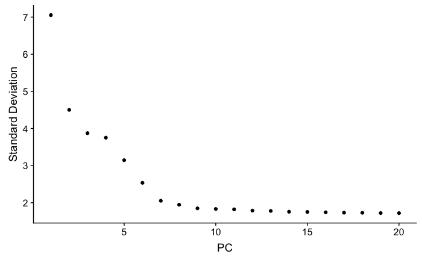

```r
ElbowPlot(pbmc)
```

Identifying the true dimensionality of a dataset can be challenging/uncertain for the user. We therefore suggest these three approaches to consider. The first is more supervised, exploring PCs to determine relevant sources of heterogeneity, and could be used in conjunction with GSEA for example. The second implements a statistical test based on a random null model, but is time-consuming for large datasets, and may not return a clear PC cutoff. The third is a heuristic that is commonly used, and can be calculated instantly. In this example, all three approaches yielded similar results, but we might have been justified in choosing anything between PC 7-12 as a cutoff.

We chose 10 here, but encourage users to consider the following:

- Dendritic cell and NK aficionados may recognize that genes strongly associated with PCs 12 and 13 define rare immune subsets (i.e. MZB1 is a marker for plasmacytoid DCs). However, these groups are so rare, they are difficult to distinguish from background noise for a dataset of this size without prior knowledge.
- We encourage users to repeat downstream analyses with a different number of PCs (10, 15, or even 50!). As you will observe, the results often do not differ dramatically.
- We advise users to err on the higher side when choosing this parameter. For example, performing downstream analyses with only 5 PCs does signifcanltly and adversely affect results.
- That being said, including too many PCs can muddle clusters further down in the pipeline; garbage in, garbage out! It’s very important to repeat downstream analysis with a different number of PCs to dial in on the appropriate number.

### Saving

Let’s again save the object to enable loading back in without having to rerun computationally intensive steps.

```r
saveRDS(pbmc, file = "./output/pbmc_tutorial.rds")
#pbmc = loadRDS("./output/pbmc_tutorial.rds")
```